# Programming Assignment 3

borhan

## 0. Introduction

This notebook contains the programming assignment 3 of Coursera course about the Data Science course by John Hopkins University. Notebook will be divided into 4 parts.

1. Plot the 30-day mortality rates for heart attack
2. Finding the best hospital in a state
3. Ranking hospitals by outcome in a state
4. Ranking hospitals in all states

The data for this assignment come from the [Hospital Compare Website](http://hospitalcompare.hhs.gov) run by the U.S. Department of Health and Human Services. The purpose of the web site is to provide data and information about the quality of care at over 4,000 Medicare-certified hospitals in the U.S. This dataset essentially covers all major U.S. hospitals. This dataset is used for a variety of purposes, including determining whether hospitals should be fined for not providing high quality care to patients.

## 1. Plot the 30-day mortality rates for heart attack

In this part, we will create a histogram about the 30-day mortality rates for heart attack. In the following code chunk we will start with loading the data inside “outcome-of-care-measure.csv” as outcome and print out the head of this dataset.

```r
outcomeData <- read.csv("outcome-of-care-measures.csv", colClasses =  "character")
head(outcomeData)
```

|  | Provider.Number | Hospital.Name | Address.1 | Address.2 | Address.3 | City | State | ZIP.Code | County.Name | Phone.Number | Hospital.30.Day.Death..Mortality..Rates.from.Heart.Attack | Comparison.to.U.S..Rate...Hospital.30.Day.Death..Mortality..Rates.from.Heart.Attack | Lower.Mortality.Estimate...Hospital.30.Day.Death..Mortality..Rates.from.Heart.Attack | Upper.Mortality.Estimate...Hospital.30.Day.Death..Mortality..Rates.from.Heart.Attack | Number.of.Patients...Hospital.30.Day.Death..Mortality..Rates.from.Heart.Attack | Footnote...Hospital.30.Day.Death..Mortality..Rates.from.Heart.Attack | Hospital.30.Day.Death..Mortality..Rates.from.Heart.Failure | Comparison.to.U.S..Rate...Hospital.30.Day.Death..Mortality..Rates.from.Heart.Failure | Lower.Mortality.Estimate...Hospital.30.Day.Death..Mortality..Rates.from.Heart.Failure | Upper.Mortality.Estimate...Hospital.30.Day.Death..Mortality..Rates.from.Heart.Failure | Number.of.Patients...Hospital.30.Day.Death..Mortality..Rates.from.Heart.Failure | Footnote...Hospital.30.Day.Death..Mortality..Rates.from.Heart.Failure | Hospital.30.Day.Death..Mortality..Rates.from.Pneumonia | Comparison.to.U.S..Rate...Hospital.30.Day.Death..Mortality..Rates.from.Pneumonia | Lower.Mortality.Estimate...Hospital.30.Day.Death..Mortality..Rates.from.Pneumonia | Upper.Mortality.Estimate...Hospital.30.Day.Death..Mortality..Rates.from.Pneumonia | Number.of.Patients...Hospital.30.Day.Death..Mortality..Rates.from.Pneumonia | Footnote...Hospital.30.Day.Death..Mortality..Rates.from.Pneumonia | Hospital.30.Day.Readmission.Rates.from.Heart.Attack | … |
| --- | --- | --- | --- | --- | --- | --- | --- | --- | --- | --- | --- | --- | --- | --- | --- | --- | --- | --- | --- | --- | --- | --- | --- | --- | --- | --- | --- | --- | --- | --- |
| 1 | 010001 | SOUTHEAST ALABAMA MEDICAL CENTER | 1108 ROSS CLARK CIRCLE |  |  | DOTHAN | AL | 36301 | HOUSTON | 3347938701 | 14.3 | No Different than U.S. National Rate | 12.1 | 17.0 | 666 |  | 11.4 | No Different than U.S. National Rate | 9.5 | 13.7 | 741 |  | 10.9 | No Different than U.S. National Rate | 8.6 | 13.7 | 371 |  | 19.0 | … |
| 2 | 010005 | MARSHALL MEDICAL CENTER SOUTH | 2505 U S HIGHWAY 431 NORTH |  |  | BOAZ | AL | 35957 | MARSHALL | 2565938310 | 18.5 | No Different than U.S. National Rate | 14.7 | 23.0 | 44 |  | 15.2 | Worse than U.S. National Rate | 12.2 | 18.8 | 234 |  | 13.9 | No Different than U.S. National Rate | 11.3 | 17.0 | 372 |  | Not Available | … |
| 3 | 010006 | ELIZA COFFEE MEMORIAL HOSPITAL | 205 MARENGO STREET |  |  | FLORENCE | AL | 35631 | LAUDERDALE | 2567688400 | 18.1 | No Different than U.S. National Rate | 14.8 | 21.8 | 329 |  | 11.3 | No Different than U.S. National Rate | 9.1 | 13.9 | 523 |  | 13.4 | No Different than U.S. National Rate | 11.2 | 15.8 | 836 |  | 17.8 | … |
| 4 | 010007 | MIZELL MEMORIAL HOSPITAL | 702 N MAIN ST |  |  | OPP | AL | 36467 | COVINGTON | 3344933541 | Not Available | Number of Cases Too Small | Not Available | Not Available | 14 | number of cases is too small (fewer than 25) to reliably tell how well the hospital is performing | 13.6 | No Different than U.S. National Rate | 10.0 | 18.2 | 113 |  | 14.9 | No Different than U.S. National Rate | 11.6 | 19.0 | 239 |  | Not Available | … |
| 5 | 010008 | CRENSHAW COMMUNITY HOSPITAL | 101 HOSPITAL CIRCLE |  |  | LUVERNE | AL | 36049 | CRENSHAW | 3343353374 | Not Available | Number of Cases Too Small | Not Available | Not Available | 9 | number of cases is too small (fewer than 25) to reliably tell how well the hospital is performing | 13.8 | No Different than U.S. National Rate | 9.9 | 18.7 | 53 |  | 15.8 | No Different than U.S. National Rate | 11.4 | 21.5 | 61 |  | Not Available | … |
| 6 | 010010 | MARSHALL MEDICAL CENTER NORTH | 8000 ALABAMA HIGHWAY 69 |  |  | GUNTERSVILLE | AL | 35976 | MARSHALL | 2565718000 | Not Available | Number of Cases Too Small | Not Available | Not Available | 22 | number of cases is too small (fewer than 25) to reliably tell how well the hospital is performing | 12.5 | No Different than U.S. National Rate | 9.9 | 15.6 | 163 |  | 8.7 | Better than U.S. National Rate | 6.8 | 11.0 | 315 |  | Not Available | … |

In the next chunk we will create a histogram that shows the frequencies of 30-mortality rates for heart attack.

```r
mortality <- as.numeric(outcomeData[,11])
```

```
NAs introduced by coercion
```

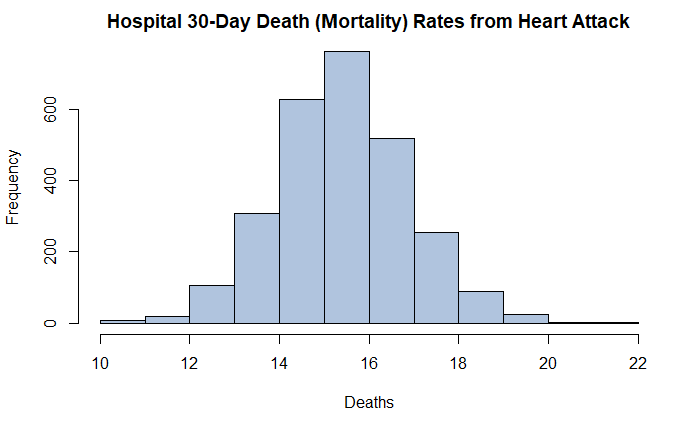

```r
hist(mortality, xlab = "Deaths", main = "Hospital 30-Day Death (Mortality) Rates from Heart Attack", col = "lightsteelblue")
```

## 2. Finding the best hospital in a state

Here, we will create a function ‘best’ that takes two arguments: the 2-character abbreviated name of a state and an outcome name. The function reads the outcome-of-care-measures.csv file and returns a character vector with the name of the hospital that has the best (i.e. lowest) 30-day mortality for the specified outcome in that state. The hospital name is the name provided in the Hospital.Name variable. The outcomes can be one of “heart attack”, “heart failure”, or “pneumonia”. Hospitals that do not have data on a particular outcome should be excluded from the set of hospitals when deciding the rankings. When a tie is encountered for the best hospital for a given outcome, the the hospital names should be sorted alphabetically and the first hospital in that set should be chosen.

```r
best <- function(state, outcome) {
  ## Check that state and outcome are valid and fix coercion warnings
  if (!state %in% outcomeData$State) {
    stop("invalid state")
  }

  stateData <- subset(outcomeData, outcomeData$State == state)
  stateData[stateData == "Not Available"] <- NA

  validOutcomes <- c("heart attack", "heart failure", "pneumonia")

  if(!outcome %in% validOutcomes) {
    stop("invalid outcome")
  }

  ## Get column numbers
  if (outcome== validOutcomes[1]) {
    index <- 11
  }
  else if (outcome == validOutcomes[2]) {
    index <- 17
  }
  else if (outcome == validOutcomes[3]) {
    index <- 23
  }

  ## Return hospital name in that stat with lowest 30-day death rate
  stateData[, c(index)] <- sapply(stateData[,c(index)], as.numeric)
  stateData <- stateData[order(stateData[,index], stateData[,"Hospital.Name"], na.last = NA),]
  stateData[1, "Hospital.Name"]
}
```

Next chunk will test the above function.

```r
best("AK", "pneumonia")
```

```
[1] "YUKON KUSKOKWIM DELTA REG HOSPITAL"
```

## 3. Ranking hospitals by outcome in a state

In this chunk, we will write a function called ‘rankhospital’ that takes three arguments: the 2-character abbreviated name of a state (state), an outcome (outcome), and the ranking of a hospital in that state for that outcome (num). The function reads the outcome-of-care-measures.csv file and returns a character vector with the name of the hospital that has the ranking specified by the num argument. Ties will be handled same as above.

```r
rankhospital <- function(state, outcome, num = "best"){
    ## Check that state and outcome are valid
  if (!state %in% outcomeData$State) {
    stop("invalid state")
  }

  stateData <- subset(outcomeData, outcomeData$State == state)
  stateData[stateData == "Not Available"] <- NA

  validOutcomes <- c("heart attack", "heart failure", "pneumonia")

  if(!outcome %in% validOutcomes) {
    stop("invalid outcome")
  }

  ## Get column numbers
  if (outcome== validOutcomes[1]) {
    index <- 11
  }
  else if (outcome == validOutcomes[2]) {
    index <- 17
  }
  else if (outcome == validOutcomes[3]) {
    index <- 23
  }
  ## Return hospital name in that state with the given rank 30-day death rate
  stateData[, c(index)] <- sapply(stateData[,c(index)], as.numeric)
  stateData <- stateData[order(stateData[,index], stateData[,"Hospital.Name"], na.last = NA),]

  if (num == "best") {
    num <- 1
  }

  else if ( num == "worst") {
    num <- nrow(stateData)
  }

  if (num > nrow(stateData)) {
    NA
  }

  else
    stateData[num, "Hospital.Name"]
}
```

Next chunk will test the above function.

```r
rankhospital("NY", "heart attack", 7)
```

```
[1] "BELLEVUE HOSPITAL CENTER"
```

## 4. Ranking hospitals in all states

In this last chunk, we will write a function called rankall that takes two arguments: an outcome name (outcome) and a hospital ranking (num). The function reads the outcome-of-care-measures.csv file and returns a 2-column data frame containing the hospital in each state that has the ranking specified in num. This one also handles the ties in the same way as above functions.

```r
rankall <- function(outcome, num = "best") {
  ## Check that state and outcome are valid
  validOutcomes <- c("heart attack", "heart failure", "pneumonia")

  if(!outcome %in% validOutcomes) {
    stop("invalid outcome")
  }

  if (!(num == "best" || num == "worst" || num%%1 ==0)) {
    stop("invalid rank")
  }

  outcomeData[outcomeData == "Not Available"] <- NA

  ## Get column numbers
  if (outcome== validOutcomes[1]) {
    index <- 11
  }
  else if (outcome == validOutcomes[2]) {
    index <- 17
  }
  else if (outcome == validOutcomes[3]) {
    index <- 23
  }

  outcomeData[,c(index)] <- sapply(outcomeData[,c(index)],as.numeric)

  ## For each state, find the hospital of the given rank return a data frame with the hospital names and the     (abbreviated) state name

  states <- unique(outcomeData$State)
  states <- sort(states)

  ranks <- data.frame(hospital = NA, state = NA)

  for (i in 1:length(states)) {
    stateData <- subset(outcomeData, outcomeData$State == states[i])
    stateData <- stateData[order(stateData[,index], stateData[,"Hospital.Name"], na.last = NA),]

    if (num == "best") {
      stateNum <- 1
    }
    else if (num == "worst") {
      stateNum <- nrow(stateData)
    }
    else {
      stateNum <- num
    }

    if (stateNum > nrow(stateData)) {
      hospitalName <- NA
    }
    else {
      hospitalName <- stateData[stateNum, "Hospital.Name"]
    }

    ranks[i,] <- c(hospitalName,states[i])
  }
  ranks
}
```

Next chunk will test the above function.

```r
r <- rankall("heart failure", 10)
as.character(subset(r, state == "NV")$hospital)
```

```
[1] "RENOWN SOUTH MEADOWS MEDICAL CENTER"
```